# DEP_3PL lab

Research background: R can be used to model dichotomous and polytomous data, and can be extremely flexible with different algorithms, item types, constraints, priors, etc.

For this lab, we will use MIRT to:

- Evaluate **model fit indices** to determine which model fits out data best.
- Summarize **classical item statistics**.
- Extract and plot **item parameters**.
- Evaluate **person-fit statistics**.

# 1. Data Preparation

Before we begin modeling, we need to prepare our dataset. This includes loading required libraries, handling missing values, and ensuring binary response data for proper estimation.

## 1.1 Clear Workspace & Load Required Libraries

```r
rm(list = ls()) # Clear environment
gc()            # Clear unused memory
```

```
##           used (Mb) gc trigger (Mb) limit (Mb) max used (Mb)
## Ncells  545979 29.2    1209780 64.7         NA   700320 37.5
## Vcells 1013930  7.8    8388608 64.0      16384  1963376 15.0
```

```r
cat("\f")       # Clear the console
```

## 1.2 Load and Download Libraries

```r
# We will only be using two packages today
library.list <- c("haven", "mirt")
for (i in 1:length(library.list)) {
  if (!library.list[i] %in% rownames(installed.packages())) {
    install.packages(library.list[i])
  }
  library(library.list[i], character.only = TRUE)
}
rm(library.list)
help(mirt)
```

## 1.3 Load Data

We just need the columns from the 2nd to the 11th, including 10 items.

```r
# Load data using haven's `read_sav`
data <- read_sav("DEPRESSION_DATA.sav")
data <- data.frame(data[, 2:11])  # Select only item response columns (columns 2 to 11)

# Check structure of the data
str(data)
```

```
## 'data.frame':    500 obs. of  10 variables:
##  $ item1 : num  1 0 0 0 1 0 1 1 1 1 ...
##   ..- attr(*, "format.spss")= chr "F11.0"
##   ..- attr(*, "display_width")= int 11
##  $ item2 : num  1 1 1 0 1 1 1 1 1 1 ...
##   ..- attr(*, "format.spss")= chr "F11.0"
##   ..- attr(*, "display_width")= int 11
##  $ item3 : num  1 1 1 1 1 0 1 1 1 1 ...
##   ..- attr(*, "format.spss")= chr "F11.0"
##   ..- attr(*, "display_width")= int 11
##  $ item4 : num  0 1 1 0 0 0 1 1 1 0 ...
##   ..- attr(*, "format.spss")= chr "F11.0"
##   ..- attr(*, "display_width")= int 11
##  $ item5 : num  1 1 1 0 0 1 1 1 0 1 ...
##   ..- attr(*, "format.spss")= chr "F11.0"
##   ..- attr(*, "display_width")= int 11
##  $ item6 : num  1 0 1 1 1 1 1 0 1 0 ...
##   ..- attr(*, "format.spss")= chr "F11.0"
##   ..- attr(*, "display_width")= int 11
##  $ item7 : num  1 0 1 1 1 1 1 0 0 1 ...
##   ..- attr(*, "format.spss")= chr "F11.0"
##   ..- attr(*, "display_width")= int 11
##  $ item8 : num  0 1 1 0 1 1 0 1 0 0 ...
##   ..- attr(*, "format.spss")= chr "F11.0"
##   ..- attr(*, "display_width")= int 11
##  $ item9 : num  0 0 0 0 1 1 1 1 1 0 ...
##   ..- attr(*, "format.spss")= chr "F11.0"
##   ..- attr(*, "display_width")= int 11
##  $ item10: num  1 1 0 0 1 0 1 0 0 0 ...
##   ..- attr(*, "format.spss")= chr "F11.0"
##   ..- attr(*, "display_width")= int 11
```

```r
# Display the first 6 rows of data
head(data)
```

|  | item1 | item2 | item3 | item4 | item5 | item6 | item7 | item8 | item9 | item10 |
| --- | --- | --- | --- | --- | --- | --- | --- | --- | --- | --- |
| 1 | 1 | 1 | 1 | 0 | 1 | 1 | 1 | 0 | 0 | 1 |
| 2 | 0 | 1 | 1 | 1 | 1 | 0 | 0 | 1 | 0 | 1 |
| 3 | 0 | 1 | 1 | 1 | 1 | 1 | 1 | 1 | 0 | 0 |
| 4 | 0 | 0 | 1 | 0 | 0 | 1 | 1 | 0 | 0 | 0 |
| 5 | 1 | 1 | 1 | 0 | 0 | 1 | 1 | 1 | 1 | 1 |
| 6 | 0 | 1 | 0 | 0 | 1 | 1 | 1 | 1 | 1 | 0 |

## 1.4 Handle Missing Values

Missing values can affect model estimation.

```r
# Check for missing values
if (any(is.na(data))) {
  stop("The dataset contains missing values. Handle missing data before analysis.")
}
```

## 1.5 Make Sure Everything is Binary

Since we are using a 3PL model, all responses must be coded as 0 (incorrect) or 1 (correct).

```r
# Ensure binary responses (0/1)
unique_values <- lapply(data, unique)
print(unique_values)
```

```
## $item1
## [1] 1 0
##
## $item2
## [1] 1 0
##
## $item3
## [1] 1 0
##
## $item4
## [1] 0 1
##
## $item5
## [1] 1 0
##
## $item6
## [1] 1 0
##
## $item7
## [1] 1 0
##
## $item8
## [1] 0 1
##
## $item9
## [1] 0 1
##
## $item10
## [1] 1 0
```

```r
if (!all(unlist(unique_values) %in% c(0, 1))) {
  stop("The dataset contains non-binary values. Ensure items are coded as 0 or 1.")
}
```

**Now that the data is clean we are good to go to fit the model!**

# 2. Utilizing Priors

The following is the commands needed to estimate a 3pl model with MIRT:

- **Data:** The name of your data, missing values should be coded as NA.
- **Model:** A string declaring how to estimate, we will use the default model = 1 since we have unidimensionality.
- **itemtype:** The type of model, we can choose Rasch, all the way to 5pl, rating scales, or partial credit models. Here we choose 3PL.
- **SE:** We want to print standard errors.
- **SE.type:** We can choose the estimation method such as SEM, MHRM, or Fisher. We will use Fisher for the Hessian EM algorithm.

## 2.1 Freely Estimated 3pl Model

First, we fit a freely estimated 3PL model without imposing any constraints.

```r
# Fit the 3PL model
model_3PL <- mirt(
  data = data,
  model = 1,
  itemtype = '3PL',
  SE = TRUE,
  SE.type = "Fisher",
  verbose = FALSE
)
```

```
## Warning: EM cycles terminated after 500 iterations.
```

```r
print(model_3PL)
```

```
##
## Call:
## mirt(data = data, model = 1, itemtype = "3PL", SE = TRUE, SE.type = "Fisher",
##     verbose = FALSE)
##
## Full-information item factor analysis with 1 factor(s).
## FAILED TO CONVERGE within 1e-04 tolerance after 500 EM iterations.
## mirt version: 1.44.0
## M-step optimizer: BFGS
## EM acceleration: Ramsay
## Number of rectangular quadrature: 61
## Latent density type: Gaussian
##
## Information matrix estimated with method: Fisher
## Second-order test: model is a possible local maximum
## Condition number of information matrix =  109796221
##
## Log-likelihood = -3063.349
## Estimated parameters: 30
## AIC = 6186.698
## BIC = 6313.136; SABIC = 6217.915
## G2 (993) = 751, p = 1
## RMSEA = 0, CFI = NaN, TLI = NaN
```

**Did you get a warning? What should we do if the model does not converge?**

In some cases, freely estimating parameters leads to instability in the guessing parameter in 3PL (Ayala, 2022; Han, 2012).

## 2.2 3pl with Guessing Prior

Similar to BILOG, MIRT uses ‘EM’, for the standard EM algorithm with fixed quadrature. However, by default, BILOG implements prior distributions on all item parameters under the 3PL model. The normal distribution is used for b, the log-normal for the a, and the beta for the c. In contrast, we have to manually set priors in MIRT.

**Since we had issues converging, we will focus on the guessing parameter**

Currently supported priors are of the form: (items, norm, mean, sd) for the normal/Gaussian, (items, lnorm, log_mean, log_sd) for log-normal, and (items, alpha, beta) for beta but we should use *norm* in this case, as suggested in the MIRT documentation:

“Internally the **g** and u parameters are transformed using a logit transformation: log(x/1-x), and can be reversed by using 1/(1+exp(−x)) following convergence. As such, when applying prior distributions to these parameters it is recommended to use a prior that ranges from **negative infinity to positive infinity**, such as the normally distributed prior via the ‘norm’ input.”

```r
param_values <- mod2values(model_3PL)

# Identify guessing parameters (g)
guessing_indices <- which(param_values$name == 'g')

# Set Logit-Normal priors for guessing (g), as recommended by Ayala (2022).
param_values$prior.type[guessing_indices] <- "norm"
param_values$prior_1[guessing_indices] <- -1.5  # Mean in logit space
param_values$prior_2[guessing_indices] <- 0.5   # SD in logit space

# Refit model with updated priors
model_3PL_prior <- mirt(
  data,
  1,
  itemtype = '3PL',
  SE = TRUE,
  verbose = FALSE,
  pars = param_values
)

# Verify priors were applied correctly
print(mod2values(model_3PL_prior))
```

```
##    group   item     class   name parnum  value lbound ubound   est const nconst
## 1    all  item1      dich     a1      1  0.589   -Inf    Inf  TRUE  none   none
## 2    all  item1      dich      d      2  1.372   -Inf    Inf  TRUE  none   none
## 3    all  item1      dich      g      3  0.182      0      1  TRUE  none   none
## 4    all  item1      dich      u      4  1.000      0      1 FALSE  none   none
## 5    all  item2      dich     a1      5  0.977   -Inf    Inf  TRUE  none   none
## 6    all  item2      dich      d      6  0.973   -Inf    Inf  TRUE  none   none
## 7    all  item2      dich      g      7  0.174      0      1  TRUE  none   none
## 8    all  item2      dich      u      8  1.000      0      1 FALSE  none   none
## 9    all  item3      dich     a1      9  0.983   -Inf    Inf  TRUE  none   none
## 10   all  item3      dich      d     10  0.493   -Inf    Inf  TRUE  none   none
## 11   all  item3      dich      g     11  0.177      0      1  TRUE  none   none
## 12   all  item3      dich      u     12  1.000      0      1 FALSE  none   none
## 13   all  item4      dich     a1     13  0.722   -Inf    Inf  TRUE  none   none
## 14   all  item4      dich      d     14  0.411   -Inf    Inf  TRUE  none   none
```

[output cut: 71 more lines]

```r
# Check the new model
print(model_3PL_prior)
```

```
##
## Call:
## mirt(data = data, model = 1, itemtype = "3PL", SE = TRUE, pars = param_values,
##     verbose = FALSE)
##
## Full-information item factor analysis with 1 factor(s).
## Converged within 1e-04 tolerance after 80 EM iterations.
## mirt version: 1.44.0
## M-step optimizer: nlminb
## EM acceleration: Ramsay
## Number of rectangular quadrature: 61
## Latent density type: Gaussian
##
## Information matrix estimated with method: Oakes
## Second-order test: model is a possible local maximum
## Condition number of information matrix =  1705.098
##
## Log-posterior = -3067.741
## Estimated parameters: 30
## AIC = 6190.106
## BIC = 6316.544; SABIC = 6221.322
## G2 (993) = 754.41, p = 1
## RMSEA = 0, CFI = NaN, TLI = NaN
```

There is no perfect prior, but utilizing a normal prior on the guessing parameter (g) in the logit space with a mean of approximately –1.5 and a standard deviation of 0.5 is a recommended choice (Ayala, 2022; Robitzsch, 2022). This relates to expected guessing probability around 18–20%, which is realistic, while still allowing for flexibility.

## 2.3 Compare Models

Now, we compare the freely estimated model to the model with the prior.

```r
# Extract coefficients for both models
coef(model_3PL, simplify = T, IRTpars = TRUE)
```

```
## $items
##            a      b     g u
## item1  0.817 -0.359 0.592 1
## item2  0.925 -1.362 0.001 1
## item3  0.876 -0.939 0.005 1
## item4  0.626 -1.147 0.014 1
## item5  1.408  0.129 0.192 1
## item6  1.104 -0.702 0.002 1
## item7  0.293 -2.238 0.014 1
## item8  5.478  0.597 0.274 1
## item9  0.394 -0.369 0.015 1
## item10 0.564  1.315 0.001 1
##
## $means
## F1
##  0
##
## $cov
##    F1
## F1  1
```

```r
coef(model_3PL_prior, simplify = T, IRTpars = TRUE)
```

```
## $items
##            a      b     g u
## item1  0.589 -2.330 0.182 1
## item2  0.977 -0.996 0.174 1
## item3  0.983 -0.502 0.177 1
## item4  0.722 -0.569 0.179 1
## item5  1.387  0.087 0.176 1
## item6  1.278 -0.329 0.173 1
## item7  0.340 -1.037 0.181 1
## item8  3.714  0.554 0.245 1
## item9  0.480  0.516 0.180 1
## item10 0.773  1.832 0.148 1
##
## $means
## F1
##  0
##
## $cov
##    F1
## F1  1
```

**Why are our estimates different?**

In 3PL, as we have learned, the parameters are more related. For example, if a guessing parameter increases, discrimination decreases, and the difficulty may shift as well. This can create issues when allowing a model to freely estimate all parameters. However, just adding a prior to the guessing parameter, has been shown to provide a more feasible, stable, and accurate item estimation (Ayala, 2022; Han, 2012).

```r
M2(model_3PL)  # Freely estimated 3PL model
```

|  | M2 | df | p | RMSEA | RMSEA_5 | RMSEA_95 | SRMSR | TLI | CFI |
| --- | --- | --- | --- | --- | --- | --- | --- | --- | --- |
| stats | 25.65744 | 25 | 0.4260557 | 0.007259497 | 0 | 0.03678788 | 0.03601289 | 0.9945566 | 0.9969759 |

```r
M2(model_3PL_prior)  # 3PL model with priors on guessing
```

|  | M2 | df | p | RMSEA | RMSEA_5 | RMSEA_95 | SRMSR | TLI | CFI |
| --- | --- | --- | --- | --- | --- | --- | --- | --- | --- |
| stats | 25.40514 | 25 | 0.4398622 | 0.005698775 | 0 | 0.03639583 | 0.0360947 | 0.9966456 | 0.9981364 |

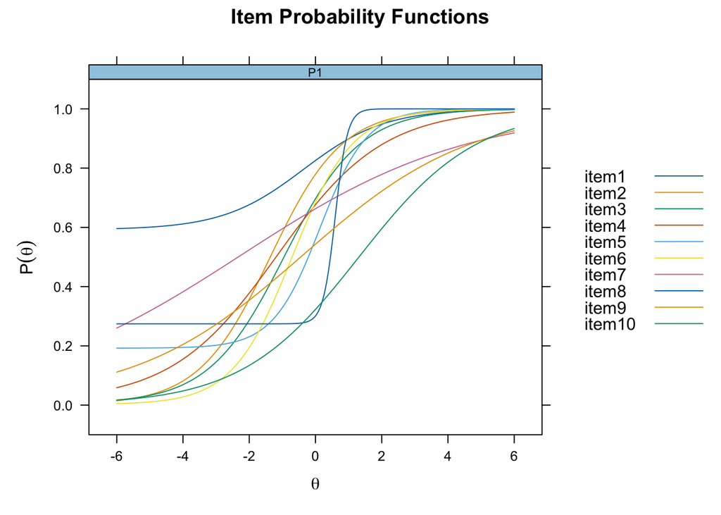

```r
# Comparing ICC plots
plot(model_3PL, type = 'trace', facet_items = F)  #Plotting ICC
```

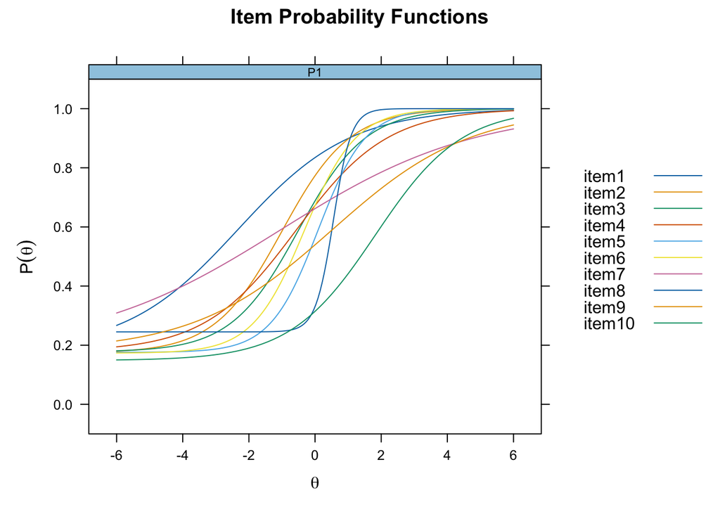

```r
plot(model_3PL_prior, type = 'trace', facet_items = F)
```

How does the item 1 change when adding a prior?

```r
# Compare Standard Error's (SEs)
summary(model_3PL)
```

```
##           F1     h2
## item1  0.433 0.1874
## item2  0.477 0.2279
## item3  0.458 0.2096
## item4  0.345 0.1191
## item5  0.637 0.4064
## item6  0.544 0.2961
## item7  0.169 0.0287
## item8  0.955 0.9120
## item9  0.226 0.0510
## item10 0.315 0.0990
##
##        SE.F1
## item1   0.42
## item2   0.24
## item3   0.23
## item4   0.29
## item5   0.19
## item6   0.20
## item7   0.56
## item8   0.14
## item9   0.41
## item10  0.31
##
## SS loadings:  2.537
## Proportion Var:  0.254
##
## Factor correlations:
##
##    F1
## F1  1
```

```r
summary(model_3PL_prior)
```

```
##           F1     h2
## item1  0.327 0.1068
## item2  0.498 0.2478
## item3  0.500 0.2500
## item4  0.391 0.1527
## item5  0.632 0.3989
## item6  0.600 0.3605
## item7  0.196 0.0384
## item8  0.909 0.8264
## item9  0.271 0.0735
## item10 0.413 0.1710
##
##        SE.F1
## item1  0.097
## item2  0.086
## item3  0.087
## item4  0.087
## item5  0.097
## item6  0.087
## item7  0.085
## item8  0.154
## item9  0.093
## item10 0.118
##
## SS loadings:  2.626
## Proportion Var:  0.263
##
## Factor correlations:
##
##    F1
## F1  1
```

Adding the prior led to lower standard errors, faster convergence, and more reasonable guessing values. Since we still want to have flexibility in the model, we will not use additional priors on the other parameters

# 3. Part 1: Classical Item Statistics

Now that we have our model, we will examine classical item statistics!

## 3.1 Model Fit

This code provides model fit indices and information on factor loadings, since we already know unidimensionality fits, we can move on to summarize the data.

```r
summary(model_3PL_prior)  # Model Summary
```

```
##           F1     h2
## item1  0.327 0.1068
## item2  0.498 0.2478
## item3  0.500 0.2500
## item4  0.391 0.1527
## item5  0.632 0.3989
## item6  0.600 0.3605
## item7  0.196 0.0384
## item8  0.909 0.8264
## item9  0.271 0.0735
## item10 0.413 0.1710
##
##        SE.F1
## item1  0.097
## item2  0.086
## item3  0.087
## item4  0.087
## item5  0.097
## item6  0.087
## item7  0.085
## item8  0.154
## item9  0.093
## item10 0.118
##
## SS loadings:  2.626
## Proportion Var:  0.263
##
## Factor correlations:
##
##    F1
## F1  1
```

## 3.2 Summarize Data

Now we will compute classical item statistics, such as the proportion correct for each item and logit difficulty.

```r
# Summarize the dataset
print(summary(data))
```

```
##      item1           item2           item3           item4           item5
##  Min.   :0.000   Min.   :0.000   Min.   :0.000   Min.   :0.000   Min.   :0.00
##  1st Qu.:1.000   1st Qu.:0.000   1st Qu.:0.000   1st Qu.:0.000   1st Qu.:0.00
##  Median :1.000   Median :1.000   Median :1.000   Median :1.000   Median :1.00
##  Mean   :0.822   Mean   :0.746   Mean   :0.672   Mean   :0.664   Mean   :0.57
##  3rd Qu.:1.000   3rd Qu.:1.000   3rd Qu.:1.000   3rd Qu.:1.000   3rd Qu.:1.00
##  Max.   :1.000   Max.   :1.000   Max.   :1.000   Max.   :1.000   Max.   :1.00
##      item6           item7          item8           item9           item10
##  Min.   :0.000   Min.   :0.00   Min.   :0.000   Min.   :0.000   Min.   :0.000
##  1st Qu.:0.000   1st Qu.:0.00   1st Qu.:0.000   1st Qu.:0.000   1st Qu.:0.000
##  Median :1.000   Median :1.00   Median :0.000   Median :1.000   Median :0.000
##  Mean   :0.652   Mean   :0.66   Mean   :0.482   Mean   :0.542   Mean   :0.334
##  3rd Qu.:1.000   3rd Qu.:1.00   3rd Qu.:1.000   3rd Qu.:1.000   3rd Qu.:1.000
##  Max.   :1.000   Max.   :1.00   Max.   :1.000   Max.   :1.000   Max.   :1.000
```

```r
# Calculate the number of correct responses per item
correct_counts <- colSums(data)
total_respondents <- nrow(data)
proportion_correct <- correct_counts / total_respondents

# Calculate the logit of the proportion correct
logit <- -log(proportion_correct / (1 - proportion_correct))

# Combine results into a summary table for items
results <- data.frame(
  N_Right = correct_counts,
  PCT = proportion_correct,
  Logit = logit
)

# Display the item summary
print(results)
```

```
##        N_Right   PCT       Logit
## item1      411 0.822 -1.52995684
## item2      373 0.746 -1.07739133
## item3      336 0.672 -0.71724473
## item4      332 0.664 -0.68117099
## item5      285 0.570 -0.28185115
## item6      326 0.652 -0.62784208
## item7      330 0.660 -0.66329422
## item8      241 0.482  0.07203113
## item9      271 0.542 -0.16839682
## item10     167 0.334  0.69014868
```

Which items have a higher proportion correct? Do you think this relates to difficulty scores?

## 3.3 Correlations

Now we compare correlations for each item.

```r
# Loop through items
for (j in 1:ncol(data)) {
  item_scores <- data[, j]
  NC_residual <- rowSums(data[, -j, drop = FALSE], na.rm = TRUE)

  # Proportion correct
  p <- mean(item_scores, na.rm = TRUE)
  q <- 1 - p

  # Means for correct/incorrect groups, and residual SD
  mean_1 <- mean(NC_residual[item_scores == 1], na.rm = TRUE)
  mean_0 <- mean(NC_residual[item_scores == 0], na.rm = TRUE)
  sd_residual <- sd(NC_residual, na.rm = TRUE)

  # Point-Biserial and Biserial Correlation
  r_pb <- ((mean_1 - mean_0) / sd_residual) * sqrt(p * q)
  r_b <- r_pb * sqrt(p * q) / dnorm(qnorm(p))

  # Print results
  cat(sprintf("Item %d: Point-Biserial = %.5f, Biserial = %.5f\n", j, r_pb, r_b))
}
```

```
## Item 1: Point-Biserial = 0.15763, Biserial = 0.23141
## Item 2: Point-Biserial = 0.24375, Biserial = 0.33111
## Item 3: Point-Biserial = 0.23890, Biserial = 0.31047
## Item 4: Point-Biserial = 0.21148, Biserial = 0.27387
## Item 5: Point-Biserial = 0.28424, Biserial = 0.35826
## Item 6: Point-Biserial = 0.29759, Biserial = 0.38351
## Item 7: Point-Biserial = 0.09808, Biserial = 0.12681
## Item 8: Point-Biserial = 0.29870, Biserial = 0.37451
## Item 9: Point-Biserial = 0.13200, Biserial = 0.16577
## Item 10: Point-Biserial = 0.15029, Biserial = 0.19480
```

The **point biserial** correlation is the pearson correlation between item score (0 or 1) and the test score (total of item scores)

$$r_{PB} = \frac{(u_j - u_x)}{\sigma^2} \sqrt{\frac{p_j}{ q_j}}$$

The **biserial** correlation estimates the relationship between the total score and the hypothetical score underlying the dichotomous item.

$$r_{b,j} = \frac{r_{Pb_j}\sqrt{p_j(1-p_j)}}{h(Z_j)}$$

In general, according to the formulas, if the item is at a medium (average) level of difficulty will have a higher item-score correlation.

**Why is point biserial correlation always smaller than biserial correlation?**

# 4. Part 2: Item Parameters

Now, we extract item parameters and evaluate item fit.

## 4.1 Extract Item Parameters

```r
# Extract coefficients in IRT parameterization
coef_3PL <- coef(model_3PL_prior, simplify = TRUE, IRTpars = TRUE)
print(coef_3PL)
```

```
## $items
##            a      b     g u
## item1  0.589 -2.330 0.182 1
## item2  0.977 -0.996 0.174 1
## item3  0.983 -0.502 0.177 1
## item4  0.722 -0.569 0.179 1
## item5  1.387  0.087 0.176 1
## item6  1.278 -0.329 0.173 1
## item7  0.340 -1.037 0.181 1
## item8  3.714  0.554 0.245 1
## item9  0.480  0.516 0.180 1
## item10 0.773  1.832 0.148 1
##
## $means
## F1
##  0
##
## $cov
##    F1
## F1  1
```

a1 (Discrimination): Measures how well an item differentiates between individuals with different ability levels. Higher values indicate high discrimination.

d (Difficulty): Indicates the ability level required for a 50% probability of a correct response. Positive values suggest harder items.

g (Guessing): The probability of guessing the correct answer. Higher values suggest substantial guessing.

u (Upper Asymptote): Fixed at 1 in most 3PL models, representing the maximum probability of a correct response.

## 4.2 Assess Item Fit

S-X2 is a special case of the Pearson’s χ2 statistic. large S-X2 values with small p-values suggest item-misfit. Are any of the values significant (p<.05)?

```r
# Assess item fit
itemfit(model_3PL_prior)
```

| item | S_X2 | df.S_X2 | RMSEA.S_X2 | p.S_X2 |
| --- | --- | --- | --- | --- |
| item1 | 9.546414 | 6 | 0.03441667 | 0.14509928 |
| item2 | 1.654921 | 5 | 0.00000000 | 0.89452922 |
| item3 | 3.839116 | 5 | 0.00000000 | 0.57280415 |
| item4 | 4.359299 | 5 | 0.00000000 | 0.49892649 |
| item5 | 4.445858 | 5 | 0.00000000 | 0.48715999 |
| item6 | 3.712596 | 5 | 0.00000000 | 0.59149060 |
| item7 | 2.747560 | 5 | 0.00000000 | 0.73883526 |
| item8 | 7.042229 | 5 | 0.02860994 | 0.21751858 |
| item9 | 4.762149 | 5 | 0.00000000 | 0.44559200 |
| item10 | 9.934817 | 5 | 0.04447339 | 0.07710339 |

Poorly fitting items should be inspected with the empirical plots/tables for unidimensional models.

In this case, all items look good!

## 4.3 ICC Curves

Now we will plot the ICCs, to better understand how each item is functioning.

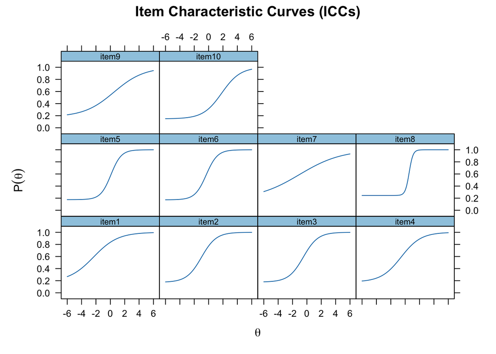

```r
# Plot Item Characteristic Curves (ICCs)
plot(model_3PL_prior, type = 'trace', main = "Item Characteristic Curves (ICCs)")
```

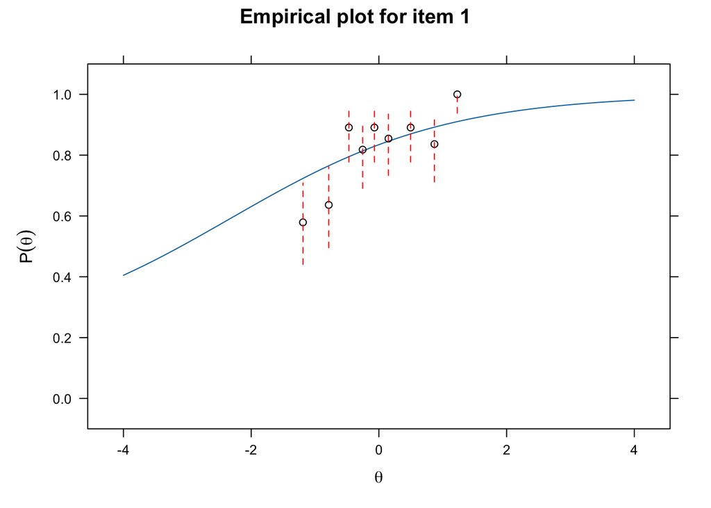

```r
# See how the data fits the ICCs
# add 'for(i in 1:length(data))' if you want all plots
itemfit(model_3PL_prior,
                      group.bins=9,
                      empirical.plot = 1,
                      empirical.CI = .95,
                      method = 'EAP')
```

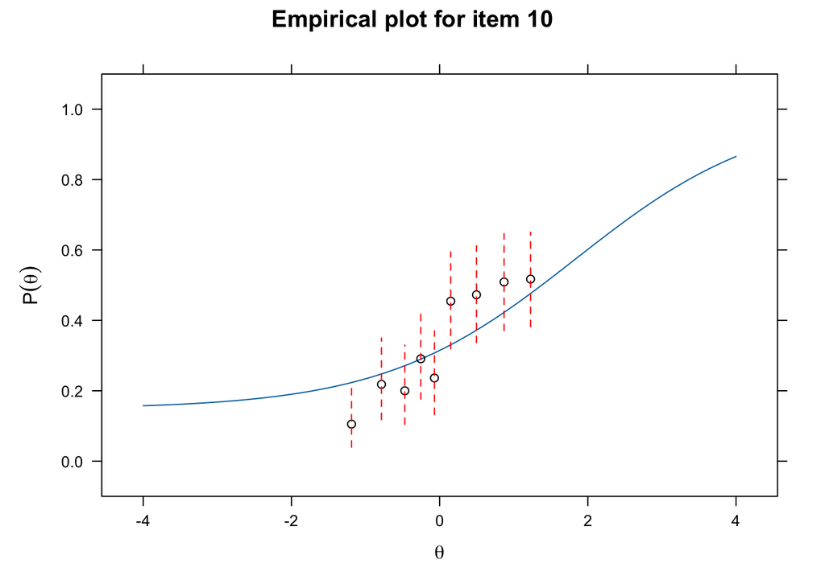

```r
itemfit(model_3PL_prior,
                      group.bins=9,
                      empirical.plot = 10,
                      empirical.CI = .95,
                      method = 'EAP')
```

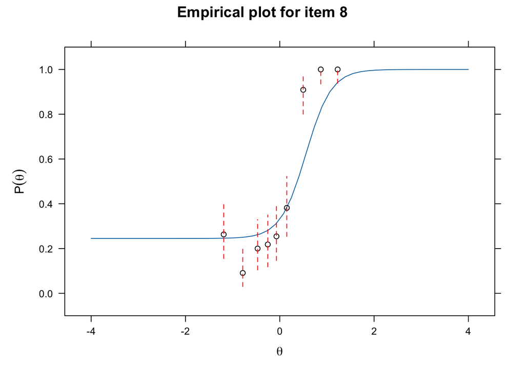

```r
itemfit(model_3PL_prior,
                      group.bins=9,
                      empirical.plot = 8,
                      empirical.CI = .95,
                      method = 'EAP')
```

Do the curves fit the data well?

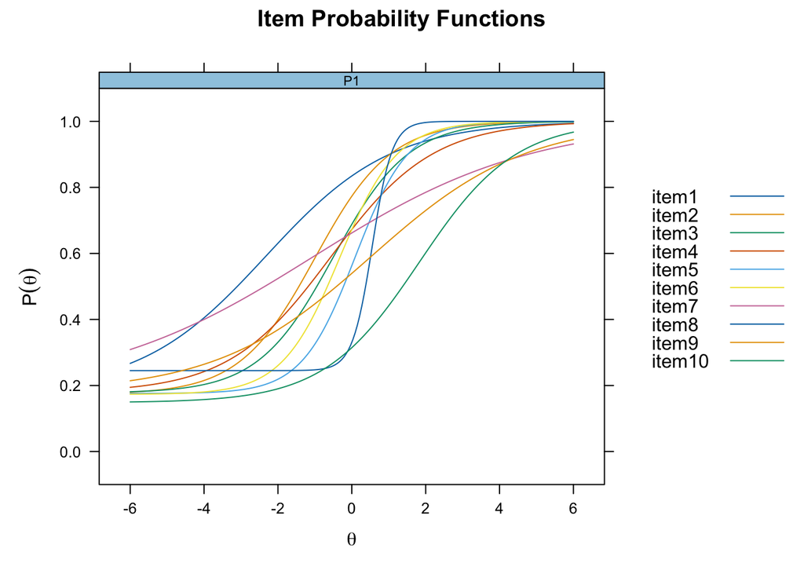

```r
# See all the ICCs in one plot
plot(model_3PL_prior, type = 'trace', facet_items = F)
```

## 4.4 Test Information

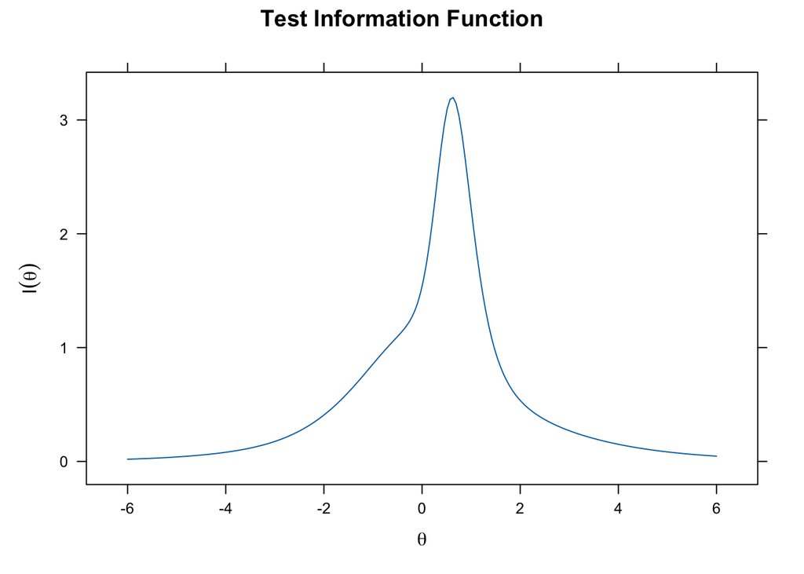

```r
# Plot test information
plot(model_3PL_prior, type='info', main='Test Information Function')
```

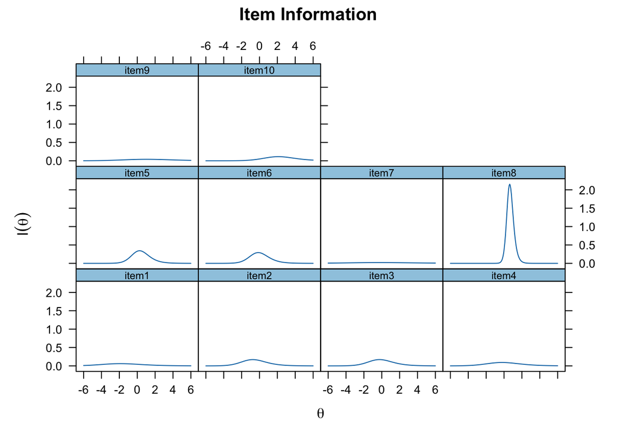

```r
# Plot item information (for item i)
plot(model_3PL_prior, type='infotrace', which.items=1:ncol(data))
```

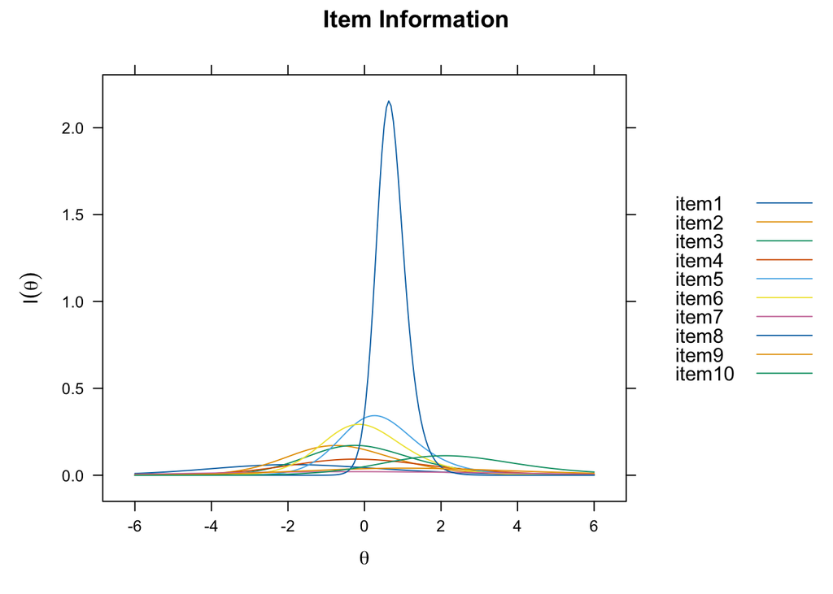

```r
# Compare item information on one plot
plot(model_3PL_prior, type = 'infotrace', facet_items = F)
```

Which item provides the most information? How does that relate to the total information?

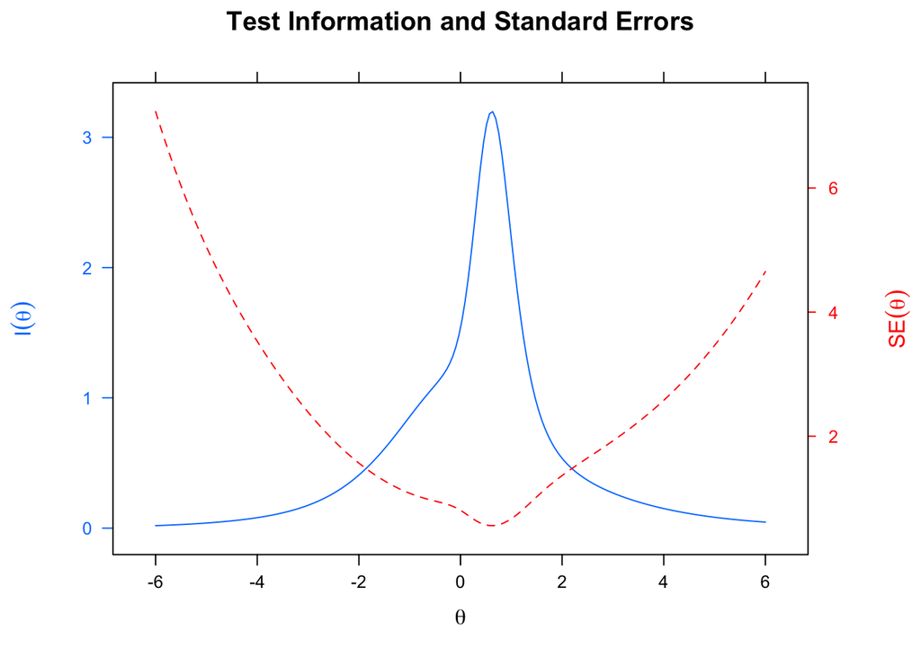

```r
# Compare Test Information and Standard Error
plot(model_3PL_prior, type = 'infoSE')
```

The standard error function is the square root of the reciprocal of the information. How does the plot reflect this?

# 5. Part 3: Examinee Parameters

Now, we assess whether individuals fit the model based on their response patterns.

## 5.1 Person Fit

Outfit and infit scores between .50 and 1.50 are generally considered acceptable (Linacre, 2002).

```r
# Calculate person fit
fit_stats <- personfit(
  model_3PL_prior,
  method = "EAP",
  Theta = NULL,
  stats.only = FALSE,
  return.resids = FALSE,
)
head(fit_stats)
```

|  | item1 | item2 | item3 | item4 | item5 | item6 | item7 | item8 | item9 | item10 | outfit | z.outfit | infit | z.infit | Zh |
| --- | --- | --- | --- | --- | --- | --- | --- | --- | --- | --- | --- | --- | --- | --- | --- |
| 1 | 1 | 1 | 1 | 0 | 1 | 1 | 1 | 0 | 0 | 1 | 0.8542260 | -0.39919144 | 0.8997970 | -0.311515548 | 0.41567510 |
| 2 | 0 | 1 | 1 | 1 | 1 | 0 | 0 | 1 | 0 | 1 | 1.6757672 | 1.82100737 | 1.5308824 | 1.759111527 | -1.97275329 |
| 3 | 0 | 1 | 1 | 1 | 1 | 1 | 1 | 1 | 0 | 0 | 1.1814781 | 0.52405979 | 0.9496491 | -0.007879197 | -0.01858099 |
| 4 | 0 | 0 | 1 | 0 | 0 | 1 | 1 | 0 | 0 | 0 | 1.0539019 | 0.30900327 | 1.0518371 | 0.325331381 | -0.25554796 |
| 5 | 1 | 1 | 1 | 0 | 0 | 1 | 1 | 1 | 1 | 1 | 0.9687838 | 0.05787564 | 1.0521994 | 0.265461188 | -0.08488908 |
| 6 | 0 | 1 | 0 | 0 | 1 | 1 | 1 | 1 | 1 | 0 | 1.4930120 | 1.49141370 | 1.3410471 | 1.263606574 | -1.39647659 |

```r
# Sum misfitting respondents
sum(fit_stats$infit > 1.5 | fit_stats$outfit > 1.5 | fit_stats$infit < .50 | fit_stats$outfit < .50)
```

```
## [1] 70
```

```r
misfit <- fit_stats[fit_stats$infit > 1.5 | fit_stats$outfit > 1.5, ]
head(misfit)  # Print the first few misfitting cases
```

|  | item1 | item2 | item3 | item4 | item5 | item6 | item7 | item8 | item9 | item10 | outfit | z.outfit | infit | z.infit | Zh |
| --- | --- | --- | --- | --- | --- | --- | --- | --- | --- | --- | --- | --- | --- | --- | --- |
| 2 | 0 | 1 | 1 | 1 | 1 | 0 | 0 | 1 | 0 | 1 | 1.675767 | 1.821007 | 1.530882 | 1.759112 | -1.972753 |
| 41 | 0 | 1 | 0 | 1 | 1 | 1 | 0 | 1 | 1 | 1 | 1.710580 | 1.540901 | 1.478995 | 1.337285 | -1.496390 |
| 93 | 0 | 0 | 1 | 1 | 1 | 1 | 0 | 0 | 0 | 1 | 1.556555 | 1.944637 | 1.433641 | 1.792295 | -2.023743 |
| 130 | 0 | 0 | 0 | 0 | 0 | 1 | 0 | 1 | 0 | 1 | 1.634169 | 2.353800 | 1.534990 | 2.336651 | -2.660596 |
| 173 | 0 | 1 | 0 | 0 | 0 | 1 | 1 | 1 | 1 | 1 | 1.639384 | 2.156087 | 1.523634 | 2.078994 | -2.371880 |
| 177 | 0 | 1 | 0 | 0 | 1 | 1 | 1 | 1 | 1 | 1 | 1.705036 | 1.713150 | 1.497719 | 1.546098 | -1.751149 |

Here you can see individual response patterns and fit indices. 70 examinees had infit or outfit values outside the acceptable range (0.5 - 1.5), suggesting that most response patterns align well with the model, but about 14% do not. This is a bit more than acceptable, so we should be cautious.

What can we do? We can **look into the response patterns** of those who fall outside the acceptable range to understand their answers better.

Depending on our findings, we can consider revising the test items or adjusting the model parameters to better accommodate abilities and different response styles.

```r
# Calculate each person's number correct
NC <- rowSums(data)

# Calculate theta
person_scores <- fscores(model_3PL_prior, method = "EAP")
Theta <- fscores(model_3PL_prior, method = "EAP", full.scores = TRUE)

# Compare number correct and theta
person_comparison <- data.frame(
  num_correct = NC,
  theta_hat = person_scores[, 1]
)

# Look at the first 6 rows
head(person_comparison)
```

|  | num_correct | theta_hat |
| --- | --- | --- |
| 1 | 7 | 0.1060866 |
| 2 | 6 | 0.2331019 |
| 3 | 7 | 0.7224127 |
| 4 | 3 | -0.9604774 |
| 5 | 8 | 0.5477364 |
| 6 | 6 | 0.1217175 |

Here we can evaluate each examinees total score along with there ability estimate.

The 1st and 3rd examinees answer the same amount of items correctly, but their ability estimates are different? How can looking at their specific response patters give a clue?

## 5.2 Reliability

Finally, we estimate the empirical reliability of the test.

```r
# Evaluate the empirical reliability
theta_se = fscores(model_3PL_prior, full.scores.SE = T)
empirical_rxx(theta_se)
```

```
##        F1
## 0.5616531
```

The empirical reliability of the test is the theta score variance divided by the sum of that variance and the error variance. Here, the reliability is 0.562 which shows that this test is reliable in some degree

# **CONCLUSION**

**We found more stable estimates when utilizing a prior.**

- We observed reduced standard errors (SE) for item parameters, indicating more precise estimates.
- The model converged faster enhancing overall efficiency of the model.
- The model with the prior demonstrated slightly better fit indices.

**Classical Item Statistics**

**Item Parameters**

**Examinee Parameters**

- 70 examinees (out of 500) had infit or outfit values outside of 1.5, suggesting that most response patterns align well with the model. This is a bit more than acceptable, so we should be cautious and evaluate the response patterns.
- The empirical reliability estimate was 0.561, indicating moderate reliability.

# Citations

https://cran.r-project.org/web/packages/mirt/mirt.pdf

Bond, T. G., & Fox, C. M. (2007). Applying the Rasch model: Fundamental measurement in the human sciences (2nd ed.). Routledge.

De Ayala, R. J. (2009). The theory and practice of item response Theory. Guilford Press.

Han, K. T. (2012). Fixing the c parameter in the three-parameter logistic model. Practical Assessment, Research, and Evaluation, 17(1). https://doi.org/10.7275/f0gz-kc87

Iwintolu, R. O., Opesemowo, O. A. G., & Adetutu, P. O. (2024). Effect of 2-PL and 3-PL models on the ability estimate in mathematics binary items. Journal on Efficiency and Responsibility in Education and Science, 17(3), 257–272. http://dx.doi.org/10.7160/eriesj.2024.170308

Linacre, J. (2002) What do infit and outfit, mean-square and standardized mean? Rasch Measurement Transactions, 16, 878.

Robitzsch, A. (2022). Four-parameter guessing model and related item response models. Mathematical and Computational Applications, 27(6), 95. https://doi.org/10.3390/mca27060095